# First tests of new MAGE model in BaM

Felipe

2025-07-31

# New features in RBaM for MAGE model calibration:

The new features in RBaM for the MAGE model calibration include:

- Model with 4 input variables:
  - **X1**: event number starting from 1.
  - **X2**: reach number starting from 1.
  - **X3**: position coordinate in the reach. Units depends on the MAGE projet.
  - **X4**: time coordinate in **seconds**.
- Model with 3 output variables. Units depends on the MAGE projet.:
  - **Y1**: water surface elevation (WSE).
  - **Y2**: discharge.
  - **Y3**: velocity.
- Calibration process multiple events **(already tested)** and multiple reaches **(not supported yet)**.
- Need to specify several folders for running several events at the same time during the calibration process.
- Spatial-temporal error model specified to each output variable: WSE, discharge and velocity error model.
- Legendre polynomial is already tested for the friction spatially distributed.
- Get simulation data using the `.BIN` file, instead of `mage_extraire`.
- **Limitations:**
  - The model can receive velocity measurements during calibration, but it is necessary to implement the velocity simulaiton in mage based on wetted area and discharge to get the simulation data.

# Setup for the MAGE model

The simulation is performed with 1200 simulations (30 NAdapt x 40 Ncycles) and 4 events. The data is stored in a text file named `CalibrationData.txt`. The data includes the following columns with -9999 as missing values:

- **Event**: event number.
- **Reach**: reach number.
- **x**: position coordinate in the reach.
- **t**: time coordinate in the reach.
- **Y_Z**: observed water surface elevation (WSE).
- **Y_Q**: observed discharge.
- **Y_V**: observed velocity.
- **Yu_Z**: uncertainty of the observed water surface elevation (WSE).
- **Yu_Q**: uncertainty of the observed discharge.
- **Yu_V**: uncertainty of the observed velocity.

```r
path <- "/home/famendezrios/Documents/These/VSCODE-R/HydroBayes/HydroBayes_git/Development/New_features_Ben/"
path_ndegree_1 <- "/home/famendezrios/Documents/These/VSCODE-R/HydroBayes/HydroBayes_git/Development/New_features_Ben_spatial"
# Read calibration data and summary
getCalData <- read.table(
  file = file.path(path, "CalibrationData.txt"),
  header = TRUE,
  stringsAsFactors = FALSE
)
knitr::kable(getCalData,
  align = "c"
)
```

| Event | Reach | x | t | Y_Z | Y_Q | Y_V | Yu_Z | Yu_Q | Yu_V |
| --- | --- | --- | --- | --- | --- | --- | --- | --- | --- |
| 1 | 1 | 0.06 | 3420 | 0.1125461 | -9999 | -9999 | 0.0009182 | -9999 | -9999 |
| 1 | 1 | 0.65 | 3420 | 0.1119325 | -9999 | -9999 | 0.0009182 | -9999 | -9999 |
| 1 | 1 | 1.65 | 3420 | 0.1110458 | -9999 | -9999 | 0.0009182 | -9999 | -9999 |
| 1 | 1 | 3.65 | 3420 | 0.1080834 | -9999 | -9999 | 0.0009182 | -9999 | -9999 |
| 1 | 1 | 5.65 | 3420 | 0.1060610 | -9999 | -9999 | 0.0009182 | -9999 | -9999 |
| 1 | 1 | 7.65 | 3420 | 0.1045160 | -9999 | -9999 | 0.0009182 | -9999 | -9999 |
| 1 | 1 | 9.65 | 3420 | 0.1021420 | -9999 | -9999 | 0.0009182 | -9999 | -9999 |
| 1 | 1 | 11.65 | 3420 | 0.1006603 | -9999 | -9999 | 0.0009182 | -9999 | -9999 |
| 2 | 1 | 0.06 | 3420 | 0.0782550 | -9999 | -9999 | 0.0005532 | -9999 | -9999 |
| 2 | 1 | 0.65 | 3420 | 0.0776414 | -9999 | -9999 | 0.0005532 | -9999 | -9999 |
| 2 | 1 | 1.65 | 3420 | 0.0766031 | -9999 | -9999 | 0.0005532 | -9999 | -9999 |
| 2 | 1 | 3.65 | 3420 | 0.0738700 | -9999 | -9999 | 0.0005532 | -9999 | -9999 |
| 2 | 1 | 5.65 | 3420 | 0.0716777 | -9999 | -9999 | 0.0005532 | -9999 | -9999 |
| 2 | 1 | 7.65 | 3420 | 0.0698072 | -9999 | -9999 | 0.0005532 | -9999 | -9999 |
| 2 | 1 | 9.65 | 3420 | 0.0672428 | -9999 | -9999 | 0.0005532 | -9999 | -9999 |
| 2 | 1 | 11.65 | 3420 | 0.0650094 | -9999 | -9999 | 0.0005532 | -9999 | -9999 |
| 3 | 1 | 0.06 | 3420 | 0.0572459 | -9999 | -9999 | 0.0004587 | -9999 | -9999 |
| 3 | 1 | 0.65 | 3420 | 0.0566323 | -9999 | -9999 | 0.0004587 | -9999 | -9999 |
| 3 | 1 | 1.65 | 3420 | 0.0560822 | -9999 | -9999 | 0.0004587 | -9999 | -9999 |
| 3 | 1 | 3.65 | 3420 | 0.0539269 | -9999 | -9999 | 0.0004587 | -9999 | -9999 |
| 3 | 1 | 5.65 | 3420 | 0.0515902 | -9999 | -9999 | 0.0004587 | -9999 | -9999 |
| 3 | 1 | 7.65 | 3420 | 0.0499854 | -9999 | -9999 | 0.0004587 | -9999 | -9999 |
| 3 | 1 | 9.65 | 3420 | 0.0476209 | -9999 | -9999 | 0.0004587 | -9999 | -9999 |
| 3 | 1 | 11.65 | 3420 | 0.0456141 | -9999 | -9999 | 0.0004587 | -9999 | -9999 |
| 4 | 1 | 0.06 | 3420 | 0.0435692 | -9999 | -9999 | 0.0004381 | -9999 | -9999 |
| 4 | 1 | 0.65 | 3420 | 0.0429556 | -9999 | -9999 | 0.0004381 | -9999 | -9999 |
| 4 | 1 | 1.65 | 3420 | 0.0422574 | -9999 | -9999 | 0.0004381 | -9999 | -9999 |
| 4 | 1 | 3.65 | 3420 | 0.0402545 | -9999 | -9999 | 0.0004381 | -9999 | -9999 |
| 4 | 1 | 5.65 | 3420 | 0.0379333 | -9999 | -9999 | 0.0004381 | -9999 | -9999 |
| 4 | 1 | 7.65 | 3420 | 0.0363895 | -9999 | -9999 | 0.0004381 | -9999 | -9999 |
| 4 | 1 | 9.65 | 3420 | 0.0339301 | -9999 | -9999 | 0.0004381 | -9999 | -9999 |
| 4 | 1 | 11.65 | 3420 | 0.0320205 | -9999 | -9999 | 0.0004381 | -9999 | -9999 |

# Case constant friction (degree=0):

## Check of MCMC results

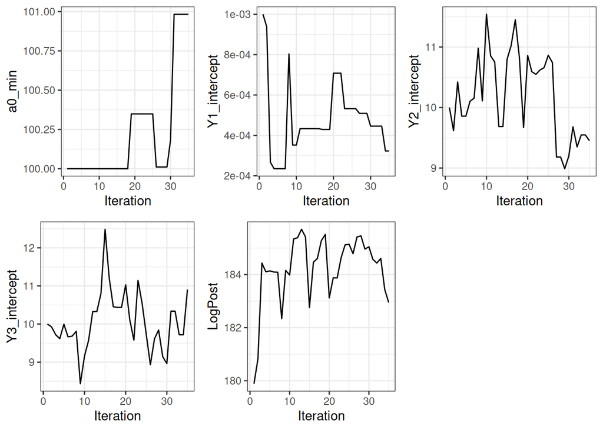

```r
mcmc <- read.table(
  file = file.path(path, "Results_MCMC.txt"),
  header = TRUE,
  stringsAsFactors = FALSE
)

# Trace plot for each parameter
plots <- tracePlot(mcmc)
gridExtra::grid.arrange(grobs = plots, ncol = 3)
```

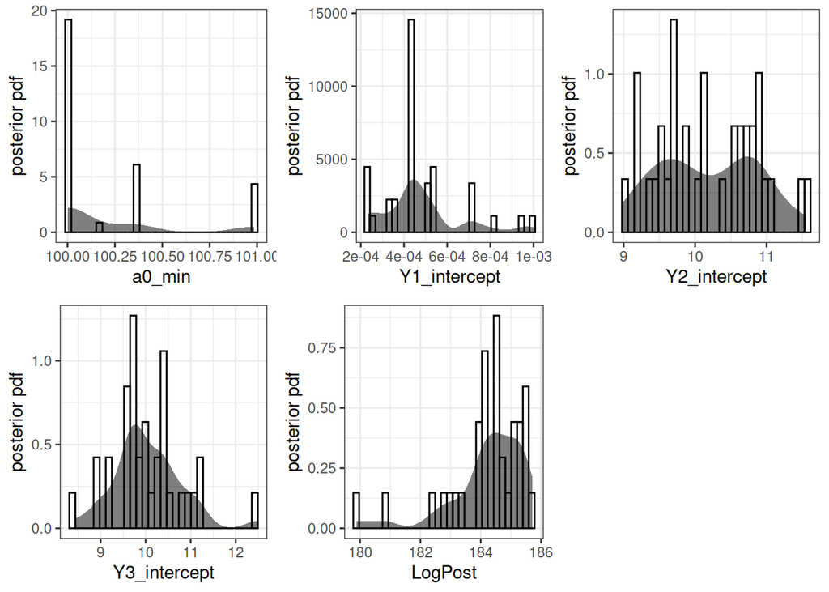

```r
# Density plot for each parameter
plots <- densityPlot(mcmc)
gridExtra::grid.arrange(grobs = plots, ncol = 3)
```

## Check summary

```r
getSummary <- read.table(
  file = file.path(path, "Results_Summary.txt"),
  header = TRUE,
  stringsAsFactors = FALSE
)

# Values of error model in meter for WSE, in m3/s for discharge and m/s for velocity.
knitr::kable(getSummary,
  align = "c"
)
```

|  | a0_min | Y1_intercept | Y2_intercept | Y3_intercept |
| --- | --- | --- | --- | --- |
| N | 1201.0000000 | 1.20100e+03 | 1.20100e+03 | 1.20100e+03 |
| Minimum | 98.2473000 | 3.67000e-05 | 7.58159e+00 | 7.44755e+00 |
| Maximum | 102.4010000 | 1.00000e-03 | 1.36931e+01 | 1.32052e+01 |
| Range | 4.1537000 | 9.63300e-04 | 6.11151e+00 | 5.75765e+00 |
| Mean | 100.0880000 | 4.78700e-04 | 1.00804e+01 | 1.00305e+01 |
| Median | 100.0920000 | 4.71500e-04 | 1.00430e+01 | 1.00158e+01 |
| Q10% | 99.2821000 | 3.02700e-04 | 8.87989e+00 | 8.72810e+00 |
| Q25% | 99.6730000 | 3.76100e-04 | 9.45221e+00 | 9.29383e+00 |
| Q75% | 100.5680000 | 5.61800e-04 | 1.07215e+01 | 1.06763e+01 |
| Q90% | 100.8450000 | 6.80300e-04 | 1.12616e+01 | 1.11748e+01 |
| St.Dev. | 0.6400700 | 1.45200e-04 | 9.30458e-01 | 9.92426e-01 |
| Variance | 0.4096890 | 0.00000e+00 | 8.65752e-01 | 9.84909e-01 |
| CV | 0.0063951 | 3.03310e-01 | 9.23037e-02 | 9.89412e-02 |
| Skewness | -0.0070218 | 1.99014e-01 | 1.10404e-01 | 2.38656e-01 |
| Kurtosis | 0.1619440 | 5.43984e-01 | 4.78620e-02 | 6.65150e-02 |
| MaxPost | 100.0260000 | 4.43300e-04 | 9.66112e+00 | 9.60403e+00 |

```r
# Zoom into the MAP and standard deviation of the error model
getSummary_zoom <- getSummary[c(11, 16), ]
getSummary_zoom[, -1] <- getSummary_zoom[, -1] * 1000 # Convert to mm for WSE and LPS for discharge, and mm/s for velocity
# Be careful with discharge and velocity, they are not observation, but only simulated values.
knitr::kable(getSummary_zoom,
  align = "c",
  caption = "Zoom into the MAP and standard deviation of the error model: WSE in mm, discharge in L/s and velocity in mm/s."
)
```

Zoom into the MAP and standard deviation of the error model: WSE in mm, discharge in L/s and velocity in mm/s.

|  | a0_min | Y1_intercept | Y2_intercept | Y3_intercept |
| --- | --- | --- | --- | --- |
| St.Dev. | 0.64007 | 0.145193 | 930.458 | 992.426 |
| MaxPost | 100.02600 | 0.443309 | 9661.120 | 9604.030 |

## Check spatial friction distribution

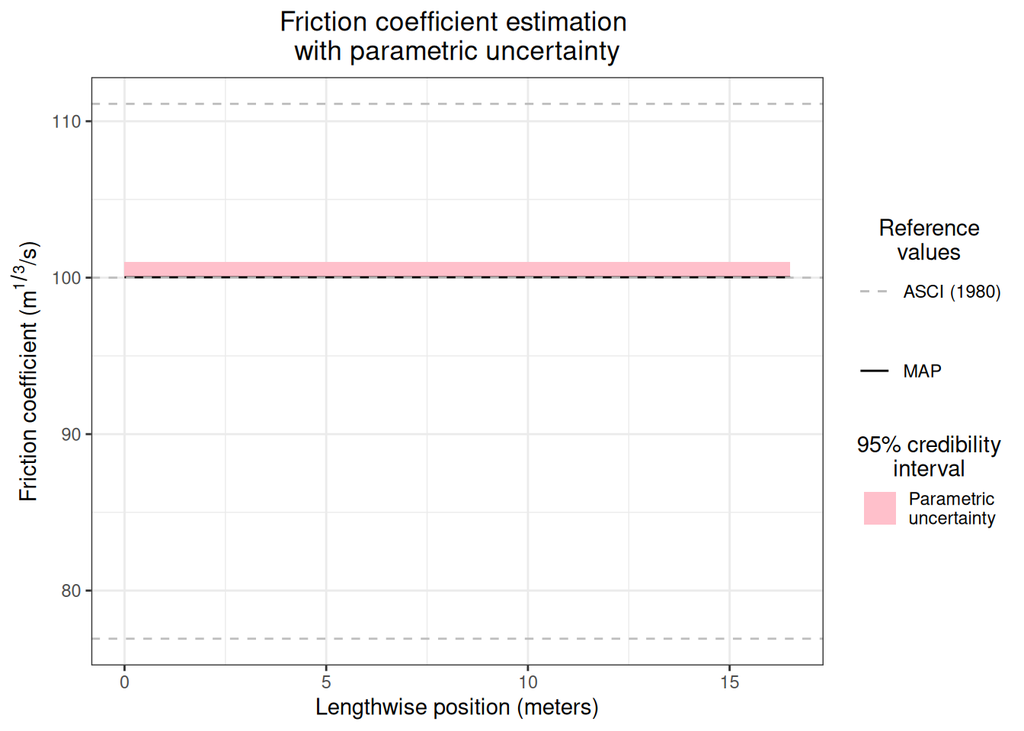

```r
n_degree <- 0

ks_literature <- data.frame(min = 1 / 0.013, max = 1 / 0.009, mean = 1 / 0.010)


matrix_zFileKmin <- read.table(file.path(path, "Zfile_Kmin.txt"), header = TRUE)

position <- read.table(file.path(path, "vector_legendre.txt"), header = TRUE)

# Get MAP simulation
MAP_param_matrix <- as.numeric(getSummary_zoom[2, c(1:(n_degree + 1))])

k_estimated_all <- as.data.frame(as.matrix(matrix_zFileKmin) %*% as.matrix(t(mcmc[, 1:(n_degree + 1)])))

k_estimated_all$KP <- position[, 1]

# Convert to long format
df_MCMC_sampling <- pivot_longer(
  k_estimated_all,
  cols = -KP,
  values_to = "Value"
) %>%
  select(KP, Value) %>%
  mutate(ID = "MCMC Sampling")

k_estimated_MAP <- as.matrix(matrix_zFileKmin) %*% MAP_param_matrix

df_MAP <- data.frame(
  KP = position[, 1],
  Value = k_estimated_MAP,
  ID = "MAP"
)

# Get 95% uncertainty for envelope curve : create ribbon data from MCMC
df_envelope <- df_MCMC_sampling %>%
  filter(ID == "MCMC Sampling") %>%
  group_by(KP) %>%
  summarise(
    ymin = quantile(Value, probs = 0.025, na.rm = TRUE),
    ymax = quantile(Value, probs = 0.975, na.rm = TRUE),
    ID = "Parametric\nuncertainty", # so we can map to fill
    .groups = "drop"
  )
ggplot() +
  geom_ribbon(
    data = df_envelope,
    aes(x = KP, ymin = ymin, ymax = ymax, fill = ID)
  ) +
  geom_line(
    data = df_MAP,
    aes(x = KP, y = Value, color = ID)
  ) +
  geom_hline(aes(yintercept = ks_literature$min, linetype = "ASCI (1980)"), color = "gray") +
  geom_hline(aes(yintercept = ks_literature$max, linetype = "ASCI (1980)"), color = "gray") +
  geom_hline(aes(yintercept = ks_literature$mean, linetype = "ASCI (1980)"), color = "gray") +
  scale_fill_manual(values = c("Parametric\nuncertainty" = "pink")) +
  scale_color_manual(values = c("MAP" = "black")) +
  # Échelle de type de ligne
  scale_linetype_manual(
    name = "Reference\nvalues",
    values = c("ASCI (1980)" = "dashed")
  ) +
  labs(
    title = "Friction coefficient estimation \nwith parametric uncertainty",
    x = "Lengthwise position (meters)",
    y = expression("Friction coefficient (m"^
      {
        1 / 3
      } * "/s)"),
    fill = "95% credibility\ninterval",
    color = NULL
  ) +
  theme_bw() +
  theme(
    plot.title = element_text(hjust = 0.5),
    legend.title = element_text(hjust = 0.5)
  )
```

## Check of residuals

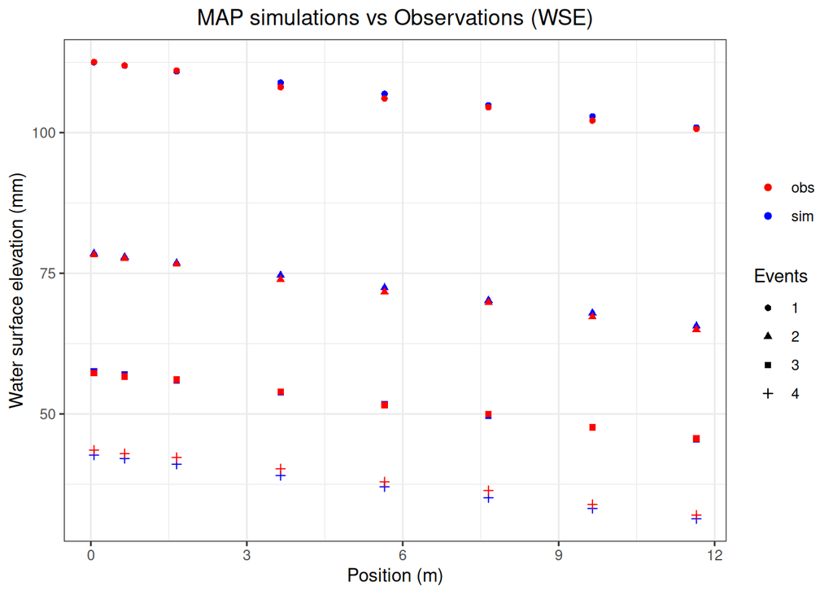

```r
# Read residuals
residuals <- read.table(
  file = file.path(path, "Results_Residuals.txt"),
  header = TRUE,
  stringsAsFactors = FALSE
)

# Replace -9999 and -1e9 with NA
residuals[residuals == -9999] <- NA
residuals[residuals == -1e9] <- NA

# Convert residuals to mm and m3/s
residuals_mm_m3_s <- data.frame(residuals[, 1:8], residuals[, -c(1:8)] * 1000)

residuals_event_mm_m3_s <- data.frame(getCalData[, 1:4], residuals_mm_m3_s)

# Plot WSE residuals
ggplot(residuals_event_mm_m3_s, aes(x = X3_obs, shape = factor(Event))) +
  geom_point(aes(y = Y1_sim, col = "sim")) +
  labs(title = "MAP simulations vs Observations (WSE)", x = "Position (m)", y = "Water surface elevation (mm)") +
  geom_point(aes(y = Y1_obs, col = "obs")) +
  scale_color_manual(values = c("sim" = "blue", "obs" = "red")) +
  labs(colour = NULL, shape = "Events") +
  theme_bw() +
  theme(plot.title = element_text(hjust = 0.5), )
```

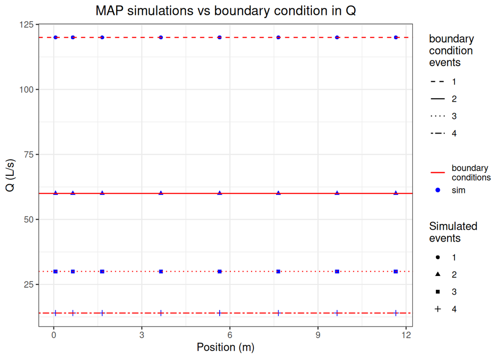

```r
# Plot Q residuals
ggplot(residuals_event_mm_m3_s, aes(x = X3_obs, shape = factor(Event))) +
  geom_point(aes(y = Y2_sim, col = "sim")) +
  labs(title = "MAP simulations vs boundary condition in Q", x = "Position (m)", y = "Q (L/s)") +
  geom_hline(aes(yintercept = 120, col = "boundary\nconditions", linetype = "1")) +
  geom_hline(aes(yintercept = 60, col = "boundary\nconditions", linetype = "2")) +
  geom_hline(aes(yintercept = 30, col = "boundary\nconditions", linetype = "3")) +
  geom_hline(aes(yintercept = 14, col = "boundary\nconditions", linetype = "4")) +
  scale_color_manual(values = c("sim" = "blue", "boundary\nconditions" = "red")) +
  scale_linetype_manual(values = c("1" = "dashed", "2" = "solid", "3" = "dotted", "4" = "twodash")) +
  labs(colour = NULL, shape = "Simulated\nevents", linetype = "boundary\ncondition\nevents") +
  theme_bw() +
  theme(plot.title = element_text(hjust = 0.5))
```

# Case linear spatial distribution of friction (degree 1):

The calibration data is the same because the only difference is the friction distribution, which is now spatially distributed with a Legendre polynomial of degree 1.

Here the files which changed:

- Config_Model: model has now a new parameter a1_min to be estimated.
- Zfile_Kmin.txt: add a new column which represents the Legendre polynomial of degree 1.
- Config_setup.txt: modify the number of columns in the Zfile_Kmin.txt file to 2.

## Check of MCMC results

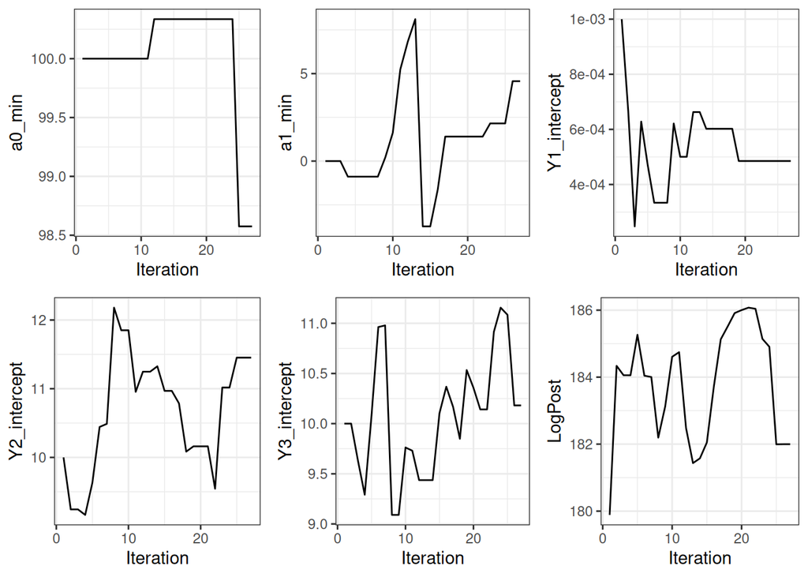

```r
mcmc <- read.table(
  file = file.path(path_ndegree_1, "Results_MCMC.txt"),
  header = TRUE,
  stringsAsFactors = FALSE
)

# Trace plot for each parameter
plots <- tracePlot(mcmc)
gridExtra::grid.arrange(grobs = plots, ncol = 3)
```

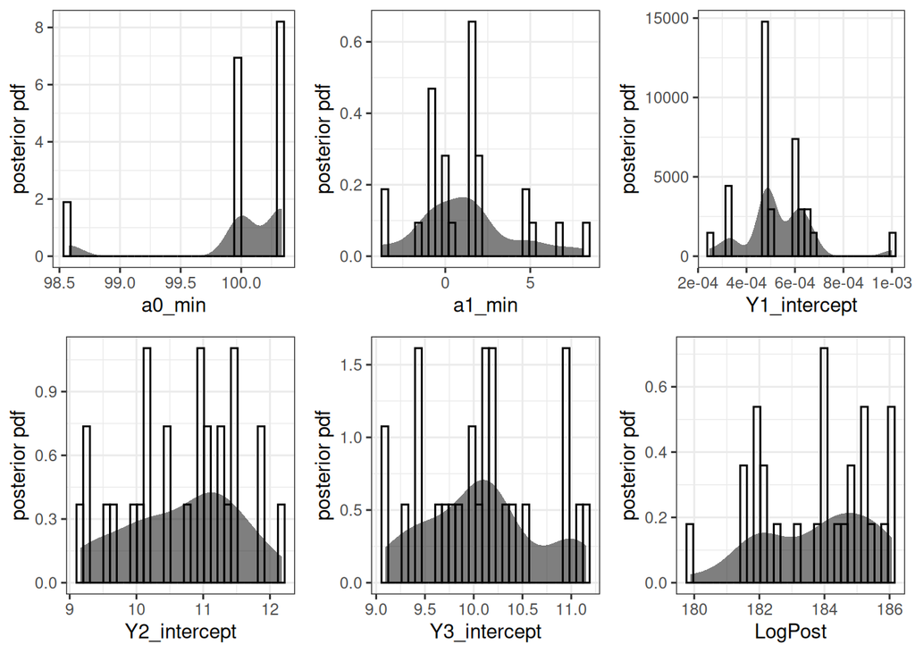

```r
# Density plot for each parameter
plots <- densityPlot(mcmc)
gridExtra::grid.arrange(grobs = plots, ncol = 3)
```

## Check summary

```r
getSummary <- read.table(
  file = file.path(path_ndegree_1, "Results_Summary.txt"),
  header = TRUE,
  stringsAsFactors = FALSE
)

# Values of error model in meter for WSE, in m3/s for discharge and m/s for velocity.
knitr::kable(getSummary,
  align = "c"
)
```

|  | a0_min | a1_min | Y1_intercept | Y2_intercept | Y3_intercept |
| --- | --- | --- | --- | --- | --- |
| N | 1.20100e+03 | 1201.000000 | 1.20100e+03 | 1.20100e+03 | 1201.000000 |
| Minimum | 9.83403e+01 | -4.081580 | 1.87000e-05 | 7.73994e+00 | 7.610170 |
| Maximum | 1.02296e+02 | 7.471180 | 1.13870e-03 | 1.38350e+01 | 14.601800 |
| Range | 3.95570e+00 | 11.552800 | 1.12000e-03 | 6.09506e+00 | 6.991630 |
| Mean | 9.99522e+01 | 2.455130 | 4.76100e-04 | 1.00444e+01 | 10.121200 |
| Median | 9.99764e+01 | 2.663380 | 4.62600e-04 | 9.96259e+00 | 10.082000 |
| Q10% | 9.91305e+01 | -0.478742 | 3.27800e-04 | 8.79487e+00 | 8.936610 |
| Q25% | 9.95450e+01 | 0.965747 | 3.86700e-04 | 9.42466e+00 | 9.400780 |
| Q75% | 1.00370e+02 | 3.770290 | 5.48300e-04 | 1.06030e+01 | 10.723400 |
| Q90% | 1.00699e+02 | 5.240170 | 6.38100e-04 | 1.13190e+01 | 11.256800 |
| St.Dev. | 6.05673e-01 | 2.171210 | 1.41400e-04 | 9.55263e-01 | 1.013150 |
| Variance | 3.66839e-01 | 4.714170 | 0.00000e+00 | 9.12527e-01 | 1.026480 |
| CV | 6.05960e-03 | 0.884359 | 2.96950e-01 | 9.51045e-02 | 0.100102 |
| Skewness | 5.92042e-02 | -0.268646 | 6.50421e-01 | 2.57218e-01 | 0.733429 |
| Kurtosis | 8.75722e-02 | -0.204230 | 2.69179e+00 | 1.87281e-01 | 1.776520 |
| MaxPost | 9.98425e+01 | 2.148380 | 4.18400e-04 | 9.92682e+00 | 10.184300 |

```r
# Zoom into the MAP and standard deviation of the error model
getSummary_zoom <- getSummary[c(11, 16), ]
getSummary_zoom[, -c(1, 2)] <- getSummary_zoom[, -c(1, 2)] * 1000 # Convert to mm for WSE and LPS for discharge, and mm/s for velocity
# Be careful with discharge and velocity, they are not observation, but only simulated values.
knitr::kable(getSummary_zoom,
  align = "c",
  caption = "Zoom into the MAP and standard deviation of the error model: WSE in mm, discharge in L/s and velocity in mm/s."
)
```

Zoom into the MAP and standard deviation of the error model: WSE in mm, discharge in L/s and velocity in mm/s.

|  | a0_min | a1_min | Y1_intercept | Y2_intercept | Y3_intercept |
| --- | --- | --- | --- | --- | --- |
| St.Dev. | 0.605673 | 2.17121 | 0.141366 | 955.263 | 1013.15 |
| MaxPost | 99.842500 | 2.14838 | 0.418430 | 9926.820 | 10184.30 |

## Check spatial friction distribution propaging parametric uncertainty

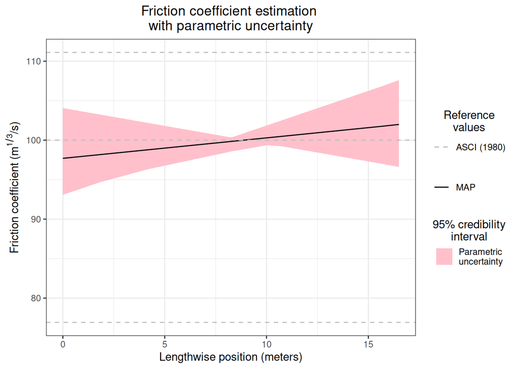

```r
n_degree <- 1

matrix_zFileKmin <- read.table(file.path(path_ndegree_1, "Zfile_Kmin.txt"), header = TRUE)

position <- read.table(file.path(path_ndegree_1, "vector_legendre.txt"), header = TRUE)

# Get MAP simulation
MAP_param_matrix <- as.numeric(getSummary_zoom[2, c(1:(n_degree + 1))])

k_estimated_all <- as.data.frame(as.matrix(matrix_zFileKmin) %*% as.matrix(t(mcmc[, 1:(n_degree + 1)])))

k_estimated_all$KP <- position[, 1]

# Convert to long format
df_MCMC_sampling <- pivot_longer(
  k_estimated_all,
  cols = -KP,
  values_to = "Value"
) %>%
  select(KP, Value) %>%
  mutate(ID = "MCMC Sampling")

k_estimated_MAP <- as.matrix(matrix_zFileKmin) %*% MAP_param_matrix

df_MAP <- data.frame(
  KP = position[, 1],
  Value = k_estimated_MAP,
  ID = "MAP"
)

# Get 95% uncertainty for envelope curve : create ribbon data from MCMC
df_envelope <- df_MCMC_sampling %>%
  filter(ID == "MCMC Sampling") %>%
  group_by(KP) %>%
  summarise(
    ymin = quantile(Value, probs = 0.025, na.rm = TRUE),
    ymax = quantile(Value, probs = 0.975, na.rm = TRUE),
    ID = "Parametric\nuncertainty", # so we can map to fill
    .groups = "drop"
  )
ggplot() +
  geom_ribbon(
    data = df_envelope,
    aes(x = KP, ymin = ymin, ymax = ymax, fill = ID)
  ) +
  geom_line(
    data = df_MAP,
    aes(x = KP, y = Value, color = ID)
  ) +
  geom_hline(aes(yintercept = ks_literature$min, linetype = "ASCI (1980)"), color = "gray") +
  geom_hline(aes(yintercept = ks_literature$max, linetype = "ASCI (1980)"), color = "gray") +
  geom_hline(aes(yintercept = ks_literature$mean, linetype = "ASCI (1980)"), color = "gray") +
  scale_fill_manual(values = c("Parametric\nuncertainty" = "pink")) +
  scale_color_manual(values = c("MAP" = "black")) +
  # Échelle de type de ligne
  scale_linetype_manual(
    name = "Reference\nvalues",
    values = c("ASCI (1980)" = "dashed")
  ) +
  labs(
    title = "Friction coefficient estimation \nwith parametric uncertainty",
    x = "Lengthwise position (meters)",
    y = expression("Friction coefficient (m"^
      {
        1 / 3
      } * "/s)"),
    fill = "95% credibility\ninterval",
    color = NULL
  ) +
  theme_bw() +
  theme(
    plot.title = element_text(hjust = 0.5),
    legend.title = element_text(hjust = 0.5)
  )
```

## Check of residuals

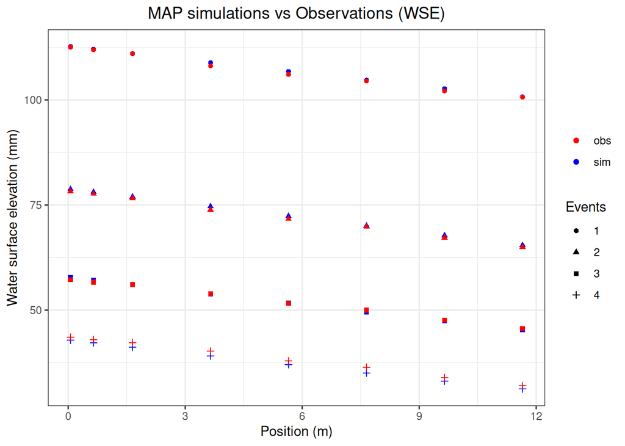

```r
# Read residuals
residuals <- read.table(
  file = file.path(path_ndegree_1, "Results_Residuals.txt"),
  header = TRUE,
  stringsAsFactors = FALSE
)

# Replace -9999 and -1e9 with NA
residuals[residuals == -9999] <- NA
residuals[residuals == -1e9] <- NA

# Convert residuals to mm and m3/s
residuals_mm_m3_s <- data.frame(residuals[, 1:8], residuals[, -c(1:8)] * 1000)

residuals_event_mm_m3_s <- data.frame(getCalData[, 1:4], residuals_mm_m3_s)

# Plot WSE residuals
ggplot(residuals_event_mm_m3_s, aes(x = X3_obs, shape = factor(Event))) +
  geom_point(aes(y = Y1_sim, col = "sim")) +
  labs(title = "MAP simulations vs Observations (WSE)", x = "Position (m)", y = "Water surface elevation (mm)") +
  geom_point(aes(y = Y1_obs, col = "obs")) +
  scale_color_manual(values = c("sim" = "blue", "obs" = "red")) +
  labs(colour = NULL, shape = "Events") +
  theme_bw() +
  theme(plot.title = element_text(hjust = 0.5), )
```

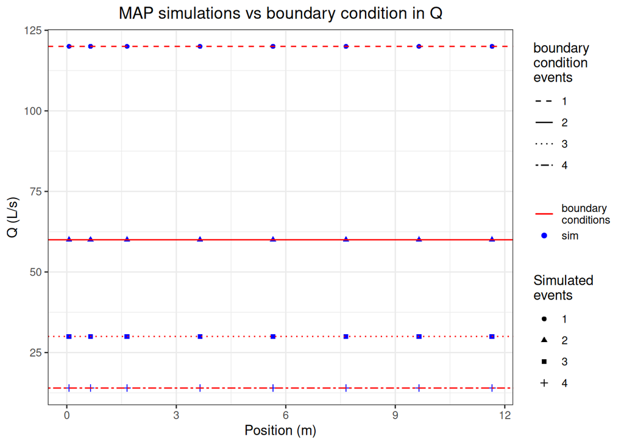

```r
# Plot Q residuals
ggplot(residuals_event_mm_m3_s, aes(x = X3_obs, shape = factor(Event))) +
  geom_point(aes(y = Y2_sim, col = "sim")) +
  labs(title = "MAP simulations vs boundary condition in Q", x = "Position (m)", y = "Q (L/s)") +
  geom_hline(aes(yintercept = 120, col = "boundary\nconditions", linetype = "1")) +
  geom_hline(aes(yintercept = 60, col = "boundary\nconditions", linetype = "2")) +
  geom_hline(aes(yintercept = 30, col = "boundary\nconditions", linetype = "3")) +
  geom_hline(aes(yintercept = 14, col = "boundary\nconditions", linetype = "4")) +
  scale_color_manual(values = c("sim" = "blue", "boundary\nconditions" = "red")) +
  scale_linetype_manual(values = c("1" = "dashed", "2" = "solid", "3" = "dotted", "4" = "twodash")) +
  labs(colour = NULL, shape = "Simulated\nevents", linetype = "boundary\ncondition\nevents") +
  theme_bw() +
  theme(plot.title = element_text(hjust = 0.5))
```

# Conclusions

- The new features are already implemented in BaM! and it is working.
- New MAGE model is fixed to 4 inputs (event, reach, x coordinate, t coordinate) and 3 outputs (WSE, discharge, velocity)
- Time coordinates will always be in seconds, because the `.BIN` file required it.
- Estimation of friction coefficients looks well and coherent with previous results using boundary conditions with all events merged in a only projet.

# To Do

- Create new structural error models for WSE, discharge and velocity
- Create a python module to implement a function to get the initial condition for each event
- Finish writing the structural error model’s equations until likelihood fonction.
- Estimate the model using RBaM functions to calculate the loglikelihood outside BaM and its restrictions.